# Rain and Bayes

Tobias Anton

last knitted: 31.03.2019 - 23:03

```r
# load required packages (and then some)
library(tidyverse)
library(afex)
library(emmeans)
library(brms)
library(rstan)
# library(ggmcmc)
library(kableExtra)

# make myself feel at home
theme_set(hrbrthemes::theme_ipsum_rc())
knitr::opts_chunk$set(out.width = "100%")

# set options
options(mc.cores = parallel::detectCores())
rstan_options(auto_write = TRUE)
afex_options(emmeans_model = "multivariate") # as advised by the author for repeated measurements
```

# Introduction & Outline

In my bachelors thesis I helped planning and then conducted and analyzed a judgement & decision making (JDM) experiment. JDM is one of the major branches of cognitive psychology with interdisciplinary branches in virtually all fields of science - not by chance are papers in the field usually starting with something like “everybody makes decisions all the time” or similar (this sentence being no exception). The group I was working with identified two major problems wit current JDM research: One is the lack of ecological validity in a majority of experiments; most people just don’t have to deal with major political decisions or have to split sums of money between strangers. The other one is a lack of reasearch into how strategies get formed and possibly rejected again or deviated from. The *Rain and Brain* experiment tries to contribute in resolving these problems.

## The “Rain and Brain” experiment

In the *Rain and Brain* experiment participants are presented ambiguous information in a relatable (that is, ecologically valid) setting based on which they have to make a decision. The first information is a numerical chance of rain, the second is “a view out the window” depicting varying degrees of cloudyness. Based on these, the participant had to decide on whether to take an umbrella with them or not.

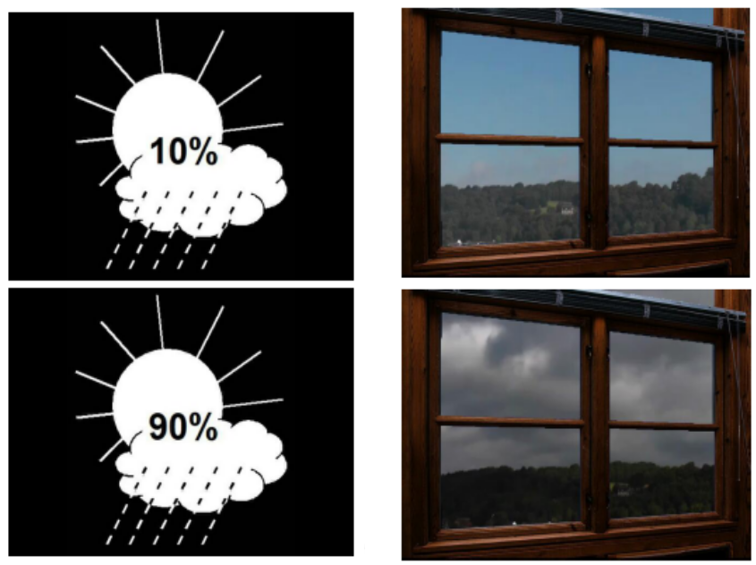

Examples of presented stimuli.

Further, in this iteration of the experiment, after every decision, the participants were shown a short video clip about how the day turned out: either a sunny or rainy day. The introduction of feedback to the experiment allowed for experimental modulation:  
The experiments consists of two runs with a short break in between. “Behind the scenes” though, so to speak, there have been three parts: The first and last block of the experimental trials of stimuli/decision/feedback sequences were identical and consisted of rather congruent forecast/sky combinations (low forecast percentages & rather clear sky, or high percentage and rather cloudy sky) with accurate feedback (it actually “rained” on 20% of the trials with a 20% forecast with rather blue sky). The second part, though, showed the complete range of weather forecasts, but only ambiguous sky-pictures and also gave rainy feedback in 90% of the trials regardless, aiming to increase participants confidence in the sky-pictures.

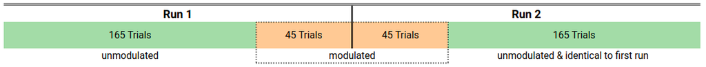

Sequence of Trials

An earlier iteration of the Rain and Brain experiment showed that people tend to place more weight on either one of the given informations. Or put otherwise: their strategies relied on either following their guts and rely on the sky pictures or they rather placed their trust in the “hard facts” implied by a numerical forecast. The aim of the experimental modulation via the feedback videos was to see if participants would alter their strategies and more often take an umbrella with them when confronted with unreliable information.

There were several depent variables in this experiment: a Preference Index (PI), a Consistency Index and the Response Time. The PI is the relative frequency of decisions in favor of the umbrella in a given forecast/sky combination, the Consistency Index intended to measure how consistent a participants decions were in those combinations and the RT is simply the time it took the participants to decide on a given situation. Here I will focus on the analysis of the PI only. In order to analyse the PI, it needs to be calculated first. The PI of stimulus combinations can be aggegated by run only, by combination of forecast/sky picture or, as was done in the original analysis, by further aggregated groups of combinations, which haven been shown to be reasonable in the former iteration of the experiment (see Preparation).

## Hypotheses

There are two main hypotheses:

As already said, certain stimulus combinations get aggregated into into larger groups. To replicate the findings of the earlier experiment, the first hypothesis is:

**H1:** The PI should increase with a higher chance of rain as implied by the stimulus combinations. The PI in every group should be different in each condition.

The second hypothesis is about the modulation:

**H2:** Since the feedback is biased towards rain, participants are expected to take an umbrella with them more often after the modulation (in Run 2, that is). The PI should increase between runs in every condition.

Both **H1** and **H2** will be split into smaller statistical hypotheses during the analysis.

### Outline of this project

First I will repeat the original analysis in a frequentist framework. After that I will repeat it in a bayesian and finally I will compare the findings and reflect upon possible differences and/or similarities.

# The data

## Raw data

```r
rab_raw <- readRDS("data/BA_behav.rds")

rab_raw %>%
  sample_n(10)
```

| ID | Run | Forecast | Window | Decision | Feedback | TTime | trial_num | grp |
| --- | --- | --- | --- | --- | --- | --- | --- | --- |
| RaBp_012 | Run 1 | 70% | 4 | Schirm | Rain | 601.3 | 152 | 70% + 4 |
| RaBp_008 | Run 2 | 30% | 2 | kein Schirm | Sunshine | 631.8 | 49 | 30% + 2 |
| RaBp_006 | Run 2 | 80% | 9 | Schirm | Rain | 162.1 | 94 | 80% + 9 |
| RaBp_015 | Run 2 | 90% | 7 | Schirm | Rain | 677.8 | 169 | 90% + 7 |
| RaBp_014 | Run 2 | 20% | 1 | kein Schirm | Sunshine | 320.1 | 127 | 20% + 1 |
| RaBp_013 | Run 1 | 90% | 5 | Schirm | Rain | 742.4 | 73 | 90% + 5 |
| RaBp_017 | Run 1 | 10% | 6 | kein Schirm | Sunshine | 423.8 | 29 | 10% + 6 |
| RaBp_009 | Run 1 | 90% | 5 | Schirm | Rain | 423.6 | 146 | 90% + 5 |
| RaBp_003 | Run 1 | 90% | 7 | Schirm | Rain | 950.3 | 129 | 90% + 7 |
| RaBp_008 | Run 2 | 30% | 5 | kein Schirm | Rain | 648.4 | 38 | 30% + 5 |

The data already is in tidy format, but still far from useable. A few words on the columns:

- `ID`: the participant identifier, 20 participants in total
- `Run`: the stage of the experiment; as stated before, conceptually there are 3 stages (first & last identical, middle stage modulated), but in order to mask this, there have been 2 Runs for the participants with a short break in between
- `Forecast`: the chance of rain as given by the forecast; from 10% to 90% in steps of 10
- `Window`: the sky picture, numbers increasing with cloudyness; 9 in total (1 = clear blue sky, 9 = many dark clouds)
- `Decision`: the decision made by the participants (sloppily labeled in german)
- `Feedback`: the feedback video shown for that trial (won’t be considered in this analysis)
- `TTime`: the response time in milliseconds
- `trial_num`: index of trial by `ID` and `Run`
- `grp`: combination of `Forecast` and `Window` (remainder of original data exploration; won’t be considered, too)

A look at the discriptives and the number of stimulus combinations:

```r
rab_raw %>%
  skimr::skim()
```

```
## Skim summary statistics
##  n obs: 8194
##  n variables: 9
##
## ── Variable type:character ──────────────────────────────────────────────────────────────────────────────────────
##  variable missing complete    n min max empty n_unique
##       grp       0     8194 8194   7   7     0       23
##        ID       0     8194 8194   8   8     0       20
##
## ── Variable type:factor ─────────────────────────────────────────────────────────────────────────────────────────
##  variable missing complete    n n_unique
##  Decision       0     8194 8194        2
##  Feedback       0     8194 8194        2
##  Forecast       0     8194 8194        9
##       Run       0     8194 8194        2
##    Window       0     8194 8194        9
##                                 top_counts ordered
##                Sch: 4536, kei: 3658, NA: 0   FALSE
##                Rai: 4557, Sun: 3637, NA: 0   FALSE
##  10%: 1040, 90%: 1040, 80%: 1000, 20%: 999    TRUE
##                Run: 4097, Run: 4097, NA: 0   FALSE
##          6: 2278, 5: 2159, 4: 2157, 1: 280    TRUE
##
## ── Variable type:integer ────────────────────────────────────────────────────────────────────────────────────────
##   variable missing complete    n   mean    sd p0 p25 p50 p75 p100     hist
##  trial_num       0     8194 8194 102.93 59.14  1  52 103 154  205 ▇▇▇▇▇▇▇▇
##
## ── Variable type:numeric ────────────────────────────────────────────────────────────────────────────────────────
##  variable missing complete    n   mean     sd p0    p25    p50    p75
##     TTime       0     8194 8194 687.45 383.71  0 425.83 604.55 852.05
##    p100     hist
##  3850.2 ▆▇▂▁▁▁▁▁
```

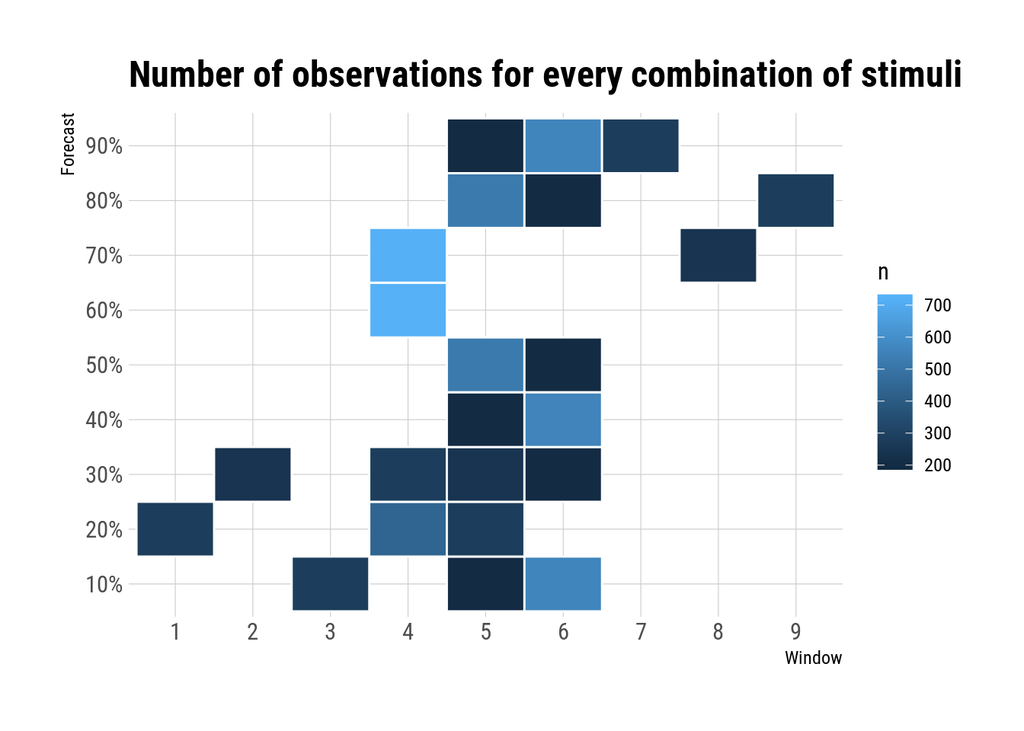

```r
rab_raw %>%
  count(Window, Forecast) %>%
  ggplot(aes(Window, Forecast, fill = n)) +
    geom_tile(color = "white", size = .5) +
    labs(title = "Number of observations for every combination of stimuli")
```

## Preparation

As stated before, the data needs to be prepared before being analyzed:

- there’s no Preference Index to analyze yet:  
  we need to calculate the relative frequency of umbrella-takings
- the data contains the modulation-trials:  
  since we are only interested in the difference in PI before and after the modulation, we need to remove all trials beyond the 165th of the first run and before the 46th of the second run
- the design matrix is strongly unbalanced:  
  this can cause huge problems with frequentist ANOVA, so we will aggregate the data into stimulus conditions in order to balance it
- no filter criteria have been defined & applied:  
  participants were asked to make a conscious decision but also not to overthink it, we therefore need to remove all trials with a decision made within 200ms and that took longer than 3 seconds

Furthermore, the observational cells are ordinal (we expect a higher PI with increasing chance of rain), which should be reflected. By recommendation of Prof. Franke, instead of using ordered R `factor`s, the ordinality will be ensured by alphabetical ordering of the labels.

```r
rab <- rab_raw %>%
  mutate(
    forecast = as.numeric(Forecast),
    Condition   = case_when(forecast <= 3 & Window <= 3 ~ "A_low_low",
                            forecast <= 3 & Window <= 6 ~ "B_mid_low",
                            forecast <= 6 & Window <= 6 ~ "C_mid_mid",
                            forecast > 6 & Window <= 6 ~ "D_mid_hi",
                            forecast > 6 & Window > 6 ~ "E_hi_hi"),
    decision = ifelse(Decision == "Schirm", 1, 0)
  ) %>%
  filter((Run == "Run 1" & trial_num <= 165) |
           (Run == "Run 2" & trial_num  >  45),
         between(TTime, 200, 3000)) %>%
  group_by(ID, Run, Condition) %>%
  summarise(
    # RT_mean = mean(TTime),
    # RT = median(TTime),
    PI = mean(decision)
  ) %>%
  ungroup() %>%
  mutate(
    Condition = factor(Condition),
    ID        = factor(ID)
  )

sample_n(rab, 10)
```

| ID | Run | Condition | PI |
| --- | --- | --- | --- |
| RaBp_012 | Run 1 | D_mid_hi | 0.974359 |
| RaBp_003 | Run 2 | E_hi_hi | 1.000000 |
| RaBp_003 | Run 2 | C_mid_mid | 0.750000 |
| RaBp_011 | Run 2 | D_mid_hi | 1.000000 |
| RaBp_011 | Run 1 | D_mid_hi | 0.974359 |
| RaBp_007 | Run 1 | E_hi_hi | 1.000000 |
| RaBp_007 | Run 2 | A_low_low | 0.050000 |
| RaBp_003 | Run 2 | A_low_low | 0.000000 |
| RaBp_018 | Run 1 | D_mid_hi | 0.875000 |
| RaBp_010 | Run 1 | B_mid_low | 0.000000 |

Again, we’ll look at number of observations per group:

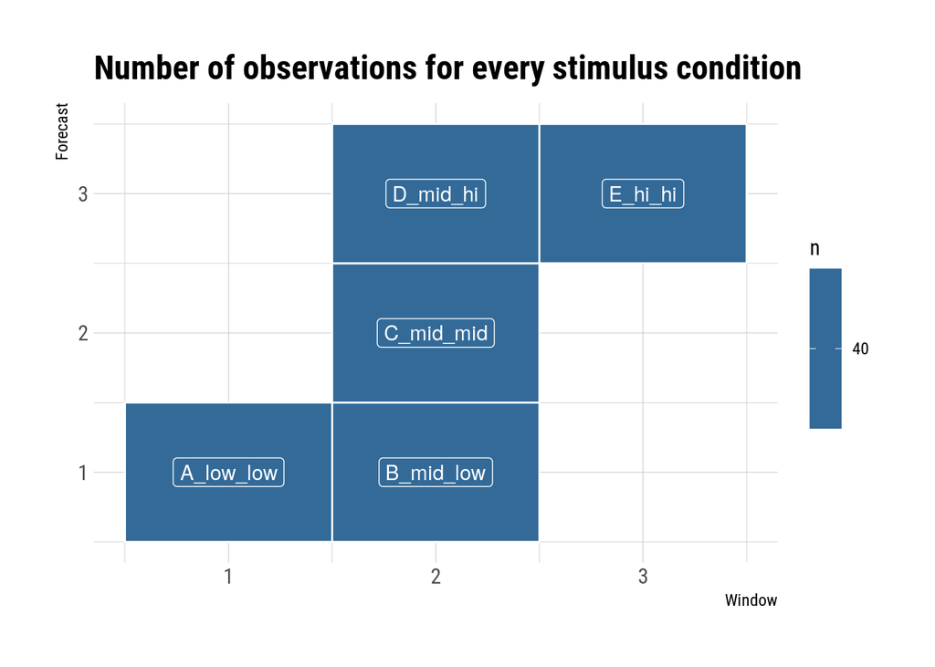

```r
rab %>%
  mutate(
    fc = case_when(str_detect(Condition, "A") ~ 1,
                   str_detect(Condition, "B") ~ 1,
                   str_detect(Condition, "C") ~ 2,
                   str_detect(Condition, "D") ~ 3,
                   str_detect(Condition, "E") ~ 3),
    sky = case_when(str_detect(Condition, "A") ~ 1,
                    str_detect(Condition, "B") ~ 2,
                    str_detect(Condition, "C") ~ 2,
                    str_detect(Condition, "D") ~ 2,
                    str_detect(Condition, "E") ~ 3)
  ) %>%
  count(sky, fc, Condition) %>%
  ggplot(aes(sky, fc, fill = n)) +
    geom_tile(color = "white", size = .5) +
    geom_label(aes(label = Condition), color = "white") +
    labs(title = "Number of observations for every stimulus condition",
         x = "Window", y = "Forecast")
```

## Inspect the prepared data

A look at a histogram of the PI looks a bit troubling, and a boxplot shows why:

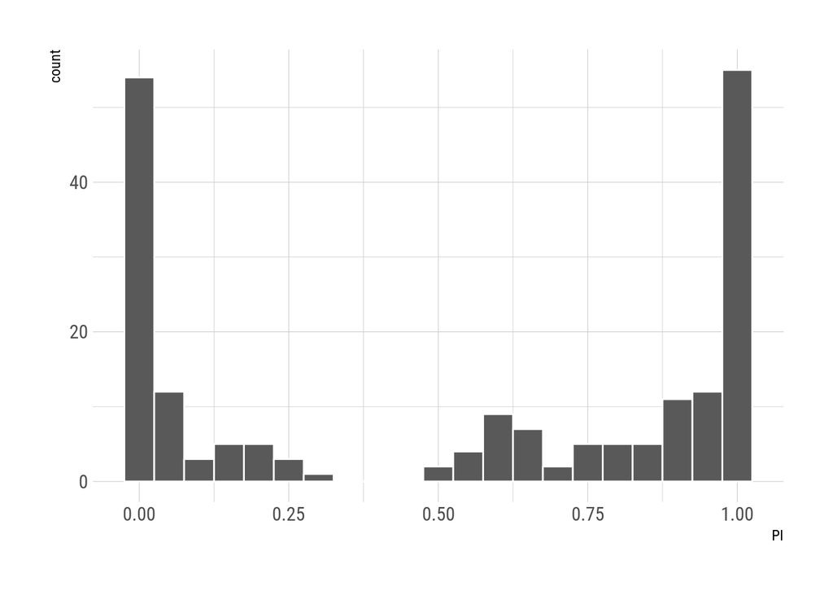

```r
ggplot(rab, aes(PI)) +
  geom_histogram(bins = 21, color = "white")
```

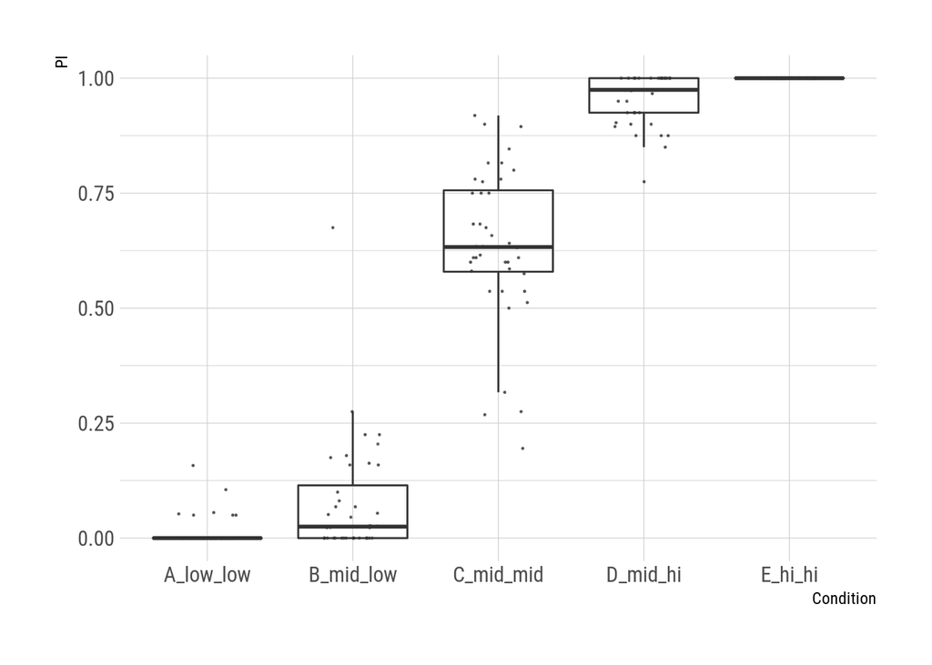

```r
ggplot(rab, aes(y = PI, x = Condition)) +
    geom_jitter(size = .2, alpha = .5, height = 0, width = .2) +
    geom_boxplot(alpha = 0)
```

This looks like a ceiling (and a floor) effect in the “A_low_low” and “E_hi_hi” groups. I’ll exclude them from the analysis and then look at the PI between experimental runs and stimulus conditions:

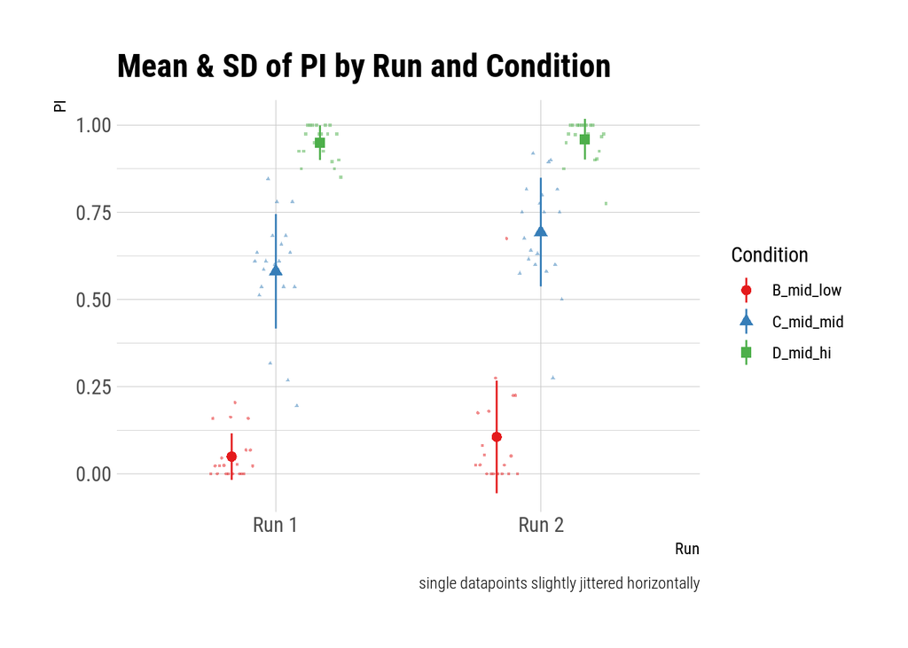

```r
rab <- filter(rab, !(Condition %in% c("A_low_low", "E_hi_hi"))) %>%
  droplevels()

sum_rab <- rab %>%
  group_by(Run, Condition) %>%
  summarise(
    mean = mean(PI),
    sd   = sd(PI)
  ) %>%
  ungroup()


ggplot(rab, aes(x = Run, y = PI, color = Condition, shape = Condition)) +
  geom_jitter(position = position_dodge2(width = .5, padding = .1),
              alpha = .5, size = .5) +
  geom_pointrange(data = sum_rab, aes(ymin = mean - sd, ymax = mean + sd,
                                      y = mean, x = Run, color = Condition),
                  position = position_dodge2(width = .5, padding = .1)) +
  scale_color_brewer(palette = "Set1") +
  labs(title = "Mean & SD of PI by Run and Condition",
       caption = "single datapoints slightly jittered horizontally")
```

We can already see some key aspects regarding the hypotheses: the PI differs greatly between conditions and seems to increase slightly between runs, which hints at an effect caused by the modulated video-feedback.

# Analysis

I will analyze the data in three steps:

1. repeat the frequentist analysis I did originally
2. re-do the analysis in Bayes
3. compare both

## Repeat Frequentist Analysis

Since this report should be mostly about the bayesian approach, I will skip an in-depth discussion about necessary assumptions and post-hoc procedures for brevity.

In the case of significant results, post-hoc analyses were conducted by calculating the estimated marginal means with a 95% Confidence Interval.

For this I’ll use the `afex` packages, which basically simplifies the code a bit and uses reasonable defaults, such as using Type III Sum of Squares by default, which should be used when expecting an interaction between predictors (which we do).

```r
# Error() declares ID as the within-subject-variable over both Run and Condition
pi_aov <- aov_car(PI ~ Run * Condition + Error(ID / Run+Condition), rab)

summary(pi_aov)
```

```
##
## Univariate Type III Repeated-Measures ANOVA Assuming Sphericity
##
##               Sum Sq num Df Error SS den Df  F value    Pr(>F)
## (Intercept)   37.152      1  0.69709     19 1012.607 < 2.2e-16 ***
## Run            0.107      1  0.15578     19   13.003  0.001883 **
## Condition     15.774      2  0.54216     38  552.793 < 2.2e-16 ***
## Run:Condition  0.053      2  0.26981     38    3.701  0.033998 *
## ---
## Signif. codes:  0 '***' 0.001 '**' 0.01 '*' 0.05 '.' 0.1 ' ' 1
##
##
## Mauchly Tests for Sphericity
##
##               Test statistic p-value
## Condition            0.94821 0.61966
## Run:Condition        0.88285 0.32581
##
##
## Greenhouse-Geisser and Huynh-Feldt Corrections
##  for Departure from Sphericity
##
##                GG eps Pr(>F[GG])
## Condition     0.95076    < 2e-16 ***
## Run:Condition 0.89513    0.03953 *
## ---
## Signif. codes:  0 '***' 0.001 '**' 0.01 '*' 0.05 '.' 0.1 ' ' 1
##
##                  HF eps   Pr(>F[HF])
## Condition     1.0536177 8.105640e-29
## Run:Condition 0.9821566 3.488051e-02
```

We’re looking at the output of the `ANOVA Assuming Sphericity`. We reject the null hypothesis (there are no differences between runs and conditions) because *p* < .05 in all factors, and conclude there to be meaningful differences between runs (*p* = .002), between conditions (*p* < .001) and their interaction (*p* = .034).

More detailed: In repeated measures ANOVA, not only homogenity of variance is important, but also sphericity. Just with normality and homogenity, sphericity brings it’s own NHST, the *Mauchly Test for Sphericity* (H0: there’s no departure from sphericity). In this case, no violation was spotted (*p* > .05), so we can ignore the Greenhouse-Geisser and Hyunh-Feldt parts of the output.

Now, since ANOVA is an omnibus test, all we know now is: there are some diiferences. Neither do we know between which levels nor how big these are. For example, looking at the interaction plot from before, it’s not too far off to assume the PI being different in every category to every other category, but which categories differ between runs is not so easily spotted. That’s where we’ll compute the estimated marginal means of the levels:

```r
pi_posthoc <- emmeans(pi_aov, ~Run*Condition)

pi_posthoc
```

```
##  Run   Condition emmean     SE df lower.CL upper.CL
##  Run.1 B_mid_low 0.0494 0.0149 19   0.0182   0.0806
##  Run.2 B_mid_low 0.1058 0.0361 19   0.0303   0.1814
##  Run.1 C_mid_mid 0.5808 0.0367 19   0.5040   0.6576
##  Run.2 C_mid_mid 0.6932 0.0348 19   0.6203   0.7661
##  Run.1 D_mid_hi  0.9496 0.0111 19   0.9264   0.9728
##  Run.2 D_mid_hi  0.9596 0.0131 19   0.9323   0.9870
##
## Confidence level used: 0.95
```

Now we can compare the CIs of every condition between runs and see that the CIs of conditions between runs overlap. This means although they seem to have increased slightly there doesn’t seem to be an effect of the modulation. We can, however, see big differences in the categories, although this merely tells us the stimuli worked as intended. We can also visualize the results in a similar fashion as before with the descriptives:

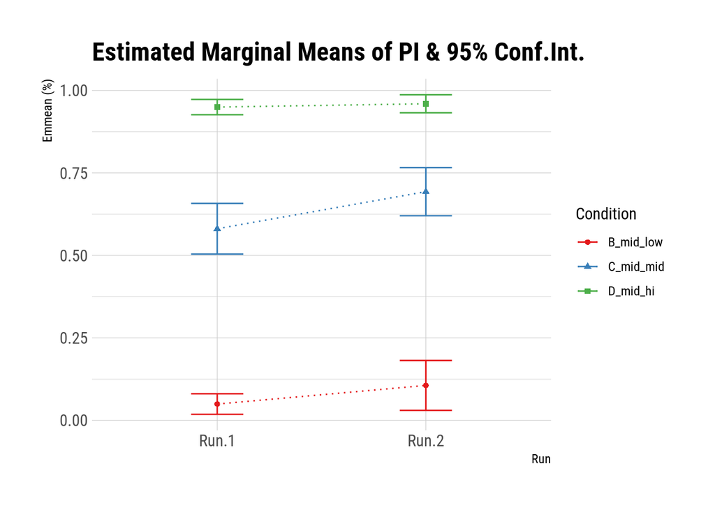

```r
pi_posthoc %>%
  as_tibble() %>%
  ggplot(aes(Run, emmean, color = Condition, group = Condition, shape = Condition)) +
    geom_errorbar(aes(ymin = lower.CL, ymax = upper.CL),
                    # position = position_dodge(width = .3),
                    width = .25) +
    geom_line(lty = "dotted") +
    geom_point() +
    scale_color_brewer(palette = "Set1") +
    labs(title = "Estimated Marginal Means of PI & 95% Conf.Int.",
         y = "Emmean (%)")
```

## Re-do analysis with `brms`

There are no requirements for equal group size (e.g. a balanced design matrix) or necessary assumptions about a parameter’s sampling distribution in BDA, which is (to put it mildly) quite convenient – although it doesn’t really matter in this case, because the data is already prepared.

We could look at a fixed effects model that only compares PI scores between Runs (and/or Conditions), but this doesn’t actually make sense, since then we ignore that participants took part in every observational cell. Likewise, a random effects model that accounts for intercepts for both Runs and Coditions also makes no sense (for the aggregated data), because every participant only went through every cell *once*, so there’s no variance to account for in that regard. We can, though, account for individual variation between subjects, just as we did in the ANOVA above.

Different from the ANOVA though, there will be no omnibus test & post-hoc comparison, but the cells of the design matrix will be directly contrasted against a baseline. This means we’re not looking at estimates of the PIs themselfes but at the differences between a given comparison, or put otherwise, a direct estimate of effect size. We can, however, get estimates of the PIs nonetheless by adding the respective differences back to the baseline.

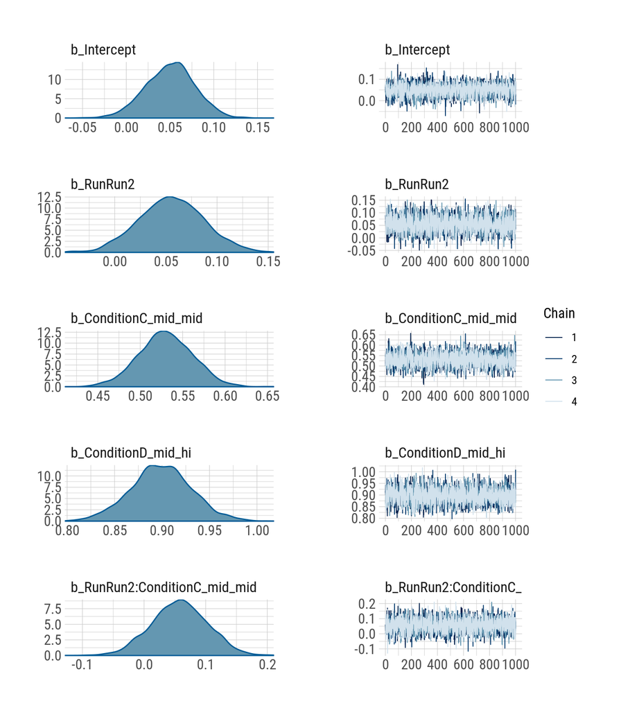

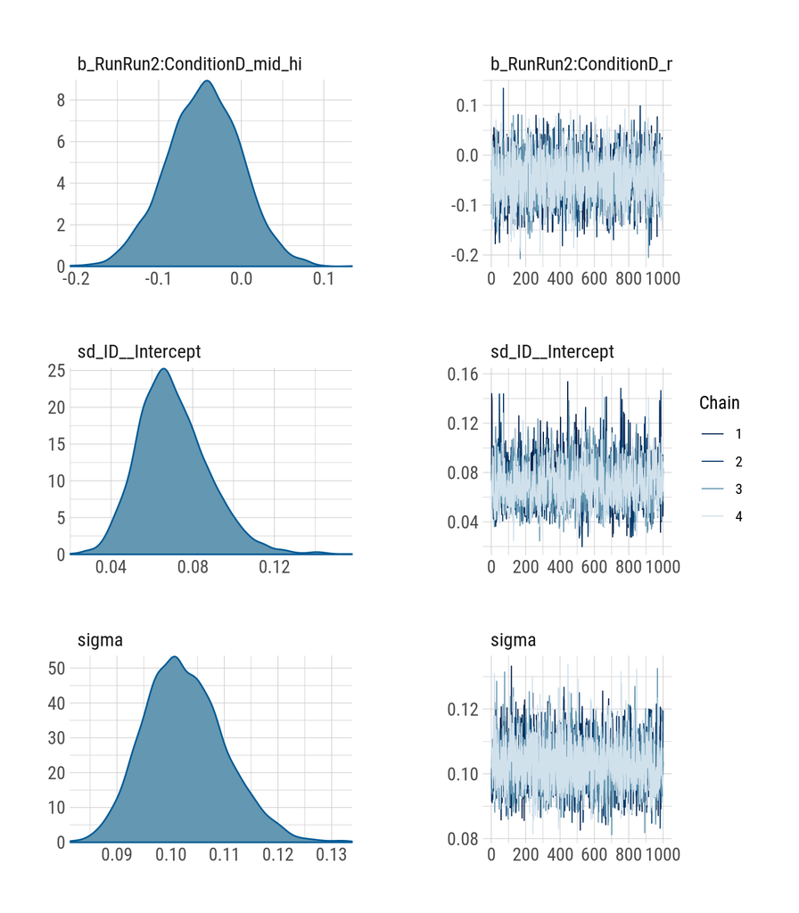

```r
# pi_brm <- brm(PI ~ Run * Condition + (1 | ID), data = rab)
# saveRDS(pi_brm, "stanfits/pi_random_subject.rds")
pi_rnd_id <- readRDS("stanfits/pi_random_subject.rds")


# when given a brmsfit object, base R's plot() function returns
# posterior density and traceplots:
plot(pi_rnd_id)
```

```r
summary(pi_rnd_id)
```

```
##  Family: gaussian
##   Links: mu = identity; sigma = identity
## Formula: PI ~ Run * Condition + (1 | ID)
##    Data: rab (Number of observations: 120)
## Samples: 4 chains, each with iter = 2000; warmup = 1000; thin = 1;
##          total post-warmup samples = 4000
##
## Group-Level Effects:
## ~ID (Number of levels: 20)
##               Estimate Est.Error l-95% CI u-95% CI Eff.Sample Rhat
## sd(Intercept)     0.07      0.02     0.04     0.11       1580 1.00
##
## Population-Level Effects:
##                            Estimate Est.Error l-95% CI u-95% CI Eff.Sample
## Intercept                      0.05      0.03    -0.01     0.10       2558
## RunRun2                        0.06      0.03    -0.01     0.12       2987
## ConditionC_mid_mid             0.53      0.03     0.47     0.59       3297
## ConditionD_mid_hi              0.90      0.03     0.83     0.96       3601
## RunRun2:ConditionC_mid_mid     0.06      0.05    -0.03     0.15       3182
## RunRun2:ConditionD_mid_hi     -0.05      0.05    -0.13     0.04       3273
##                            Rhat
## Intercept                  1.00
## RunRun2                    1.00
## ConditionC_mid_mid         1.00
## ConditionD_mid_hi          1.00
## RunRun2:ConditionC_mid_mid 1.00
## RunRun2:ConditionD_mid_hi  1.00
##
## Family Specific Parameters:
##       Estimate Est.Error l-95% CI u-95% CI Eff.Sample Rhat
## sigma     0.10      0.01     0.09     0.12       3803 1.00
##
## Samples were drawn using sampling(NUTS). For each parameter, Eff.Sample
## is a crude measure of effective sample size, and Rhat is the potential
## scale reduction factor on split chains (at convergence, Rhat = 1).
```

These traceplots definitely look like [“a bunch of hairy caterpillars madly in love with each other”](https://michael-franke.github.io/BDACM_2017/slides/06_MCMC_unshined.html#33), which is good. A look at the summary statistics tells us all $\hat{R}$ values are approximately 1, also good. This means we can continue with the analysis.

Next up is calculating the likelihood for each hypothesis being true as well as the differences in PIs with a 95% Credible Interval:

```r
# prepare table
h1 <- "H1: PI between Conditions"
h2 <- "H2: PI between Runs"

h11 <- "Run 1: Mid-Low < Mid-Mid"
h12 <- "Run 1: Mid-Mid < Mid-Hi"
h13 <- "Run 2: Mid-Low < Mid-Mid"
h14 <- "Run 2: Mid-Mid < Mid-Hi"

h21 <- "Mid-Low: Run 1 < Run 2"
h22 <- "Mid-Mid: Run 1 < Run 2"
h23 <- "Mid-Hi: Run 1 < Run 2"

sub_hypotheses <- c(h11, h12, h13, h14, h21, h22, h23)

# calculate probabilities & effects
m1_estimates <- posterior_samples(pi_rnd_id) %>%
  transmute(
    r1_mi_lo = b_Intercept,
    r2_mi_lo = b_Intercept + b_RunRun2,
    r1_mi_mi = b_Intercept + b_ConditionC_mid_mid,
    r2_mi_mi = b_Intercept + b_ConditionC_mid_mid + b_RunRun2 + `b_RunRun2:ConditionC_mid_mid`,
    r1_mi_hi = b_Intercept + b_ConditionD_mid_hi,
    r2_mi_hi = b_Intercept + b_ConditionD_mid_hi + b_RunRun2 + `b_RunRun2:ConditionD_mid_hi`
  )

m1_probs <- m1_estimates %>%
  summarise(
    h11 = mean(r1_mi_lo < r1_mi_mi),
    h12 = mean(r1_mi_mi < r1_mi_hi),
    h13 = mean(r2_mi_lo < r2_mi_mi),
    h14 = mean(r2_mi_mi < r2_mi_hi),
    h21 = mean(r1_mi_lo < r2_mi_lo),
    h22 = mean(r1_mi_mi < r2_mi_mi),
    h23 = mean(r1_mi_hi < r2_mi_hi)
  ) %>%
  gather(Comparison, Probability)

m1_diffs <- m1_estimates %>%
  transmute(
    h11 = r1_mi_mi - r1_mi_lo,
    h12 = r1_mi_hi - r1_mi_mi,
    h13 = r2_mi_mi - r2_mi_lo,
    h14 = r2_mi_hi - r2_mi_mi,
    h21 = r2_mi_lo - r1_mi_lo,
    h22 = r2_mi_mi - r1_mi_mi,
    h23 = r2_mi_hi - r1_mi_hi
  ) %>%
  gather(hypo, smpl) %>%
  group_by(hypo) %>%
  summarise(
    difference = mean(smpl),
    CI_lo = quantile(smpl, .025),
    CI_up = quantile(smpl, .975)
  )
```

```r
# print results in a nice table
tibble(
  # "Main Hypothesis" = c(rep(h1, 4), rep(h2, 3)),
  "Comparison" = sub_hypotheses,
  "Likelihood" = m1_probs$Probability
) %>%
  kable(caption = "Likelihoods for each (sub-) hypothesis") %>%
  kable_styling(c("striped", "condensed"), full_width = TRUE) %>%
  pack_rows(h1, 1, 4, label_row_css = "background-color: #158CBA; color: #fff;") %>%
  pack_rows(h2, 5, 7, label_row_css = "background-color: #158CBA; color: #fff;")
```

Likelihoods for each (sub-) hypothesis

| Comparison | Likelihood |
| --- | --- |
| **H1: PI between Conditions** |  |
| Run 1: Mid-Low < Mid-Mid | 1.00000 |
| Run 1: Mid-Mid < Mid-Hi | 1.00000 |
| Run 2: Mid-Low < Mid-Mid | 1.00000 |
| Run 2: Mid-Mid < Mid-Hi | 1.00000 |
| **H2: PI between Runs** |  |
| Mid-Low: Run 1 < Run 2 | 0.95850 |
| Mid-Mid: Run 1 < Run 2 | 0.99950 |
| Mid-Hi: Run 1 < Run 2 | 0.63025 |

We can now conclude every hypothesis to be true, except for H2.3 (“PI in condition Mid-Hi increases between runs”), at least to some degree. When inspecting the differences in the PI, the results become more nuanced, though: For all comparisons regarding **H1**, we can still conclude huge differences between conditions, as no CI of the differences includes 0.

```r
m1_diffs %>%
  map_if(is.numeric, round, 3) %>%
  as_tibble() %>%
  transmute(
    "Comparison" = str_replace(sub_hypotheses, "<", "to"),
    "PI Difference" = difference,
    "95% Cred.Int." = paste0("[", CI_lo, "; ", CI_up, "]")
  ) %>%
  kable(caption = "Differences in comparisons for each (sub-) hypothesis") %>%
  kable_styling(c("striped", "condensed"), full_width = TRUE) %>%
  pack_rows(h1, 1, 4, label_row_css = "background-color: #158CBA; color: #fff;") %>%
  pack_rows(h2, 5, 7, label_row_css = "background-color: #158CBA; color: #fff;")
```

Differences in comparisons for each (sub-) hypothesis

| Comparison | PI Difference | 95% Cred.Int. |
| --- | --- | --- |
| **H1: PI between Conditions** |  |  |
| Run 1: Mid-Low to Mid-Mid | 0.530 | [0.467; 0.591] |
| Run 1: Mid-Mid to Mid-Hi | 0.369 | [0.304; 0.43] |
| Run 2: Mid-Low to Mid-Mid | 0.588 | [0.524; 0.654] |
| Run 2: Mid-Mid to Mid-Hi | 0.266 | [0.2; 0.332] |
| **H2: PI between Runs** |  |  |
| Mid-Low: Run 1 to Run 2 | 0.056 | [-0.006; 0.118] |
| Mid-Mid: Run 1 to Run 2 | 0.113 | [0.047; 0.177] |
| Mid-Hi: Run 1 to Run 2 | 0.010 | [-0.056; 0.075] |

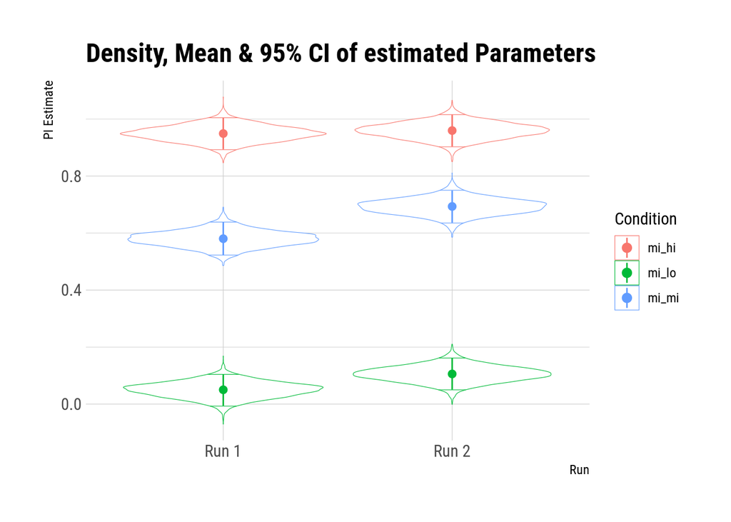

```r
m1_plot_raw <- m1_estimates %>%
  gather(Param, Samples) %>%
  mutate(
    Run = ifelse(str_detect(Param, "r1"), "Run 1", "Run 2"),
    Condition = str_remove_all(Param, "r\\d_")
  )

m1_plot_sum <- m1_plot_raw %>%
  group_by(Run, Condition) %>%
  summarise(
    mean = mean(Samples),
    q025 = quantile(Samples, .025),
    q975 = quantile(Samples, .975)
  )

ggplot(m1_plot_raw, aes(x = Run, y = Samples, color = Condition)) +
  geom_violin(draw_quantiles = c(.025, .975),
              position = "identity", size = .2) +
  # geom_jitter(data = rab, aes(y = PI),
  #             size = .5, alpha = .5, height = 0, width = .2) +
  geom_pointrange(data = m1_plot_sum, aes(y = mean, ymin = q025, ymax = q975),
                  fatten = 3) +
  labs(y = "PI Estimate", title = "Density, Mean & 95% CI of estimated Parameters")
```

# Comparison & Conclusion

Both procedures lead to the same conclusion about **H1**: the constructed stimulus conditions are well distinguishable in terms of Preference Index. Looking at the descriptives though, every other result would be highly surprising.

In the bayesian data analysis though, I looked at two ways to answer the question of wheter or not the modulation increases PI: the likelihood of the hypothesis being true on the one hand, and the Credible Interval of the difference between runs on the other. Because we can make direct statements about the parameters of interest via their posterior distribution, this allows us to draw conclusions that are more reasonable, less arbitrarily restricted and overall more informative.  
The result of H2.1 (difference between runs in condition “mid-low”) is a perfect example: Even though the 95% CI still contains 0, the likelihood of the difference being > 0 is 95.85%. Therefore we may still conclude that there is an effect to be found, just not in this particular experiment. For example one might conduct a repetition of the experiment with a larger sample size to get a narrower estimate of the effect.

My interpretation of the results and by that my opinion on the experiment changed quite a bit. When before I thought it didn’t work out as intended at all, not only does it now look like it actually did work, but also it might actually be worth to look into the design again, make some (still much needed) adjustments and repeat the experiment.